# Analyse descriptive des donnees opportunistes du GMB

2025-07-16

# 1 Statistiques descriptives

```r
Total <- Total %>%
  dplyr::mutate_at(c("bdd_rgn",
              "ett_blg", "tchnq_b",
              "communs", "obsrvtr",
              "famille", "ordre",
              "nm_vrnc", "nom_vld"),
            .funs = as.factor)%>%
  dplyr::rename(bdd_originale = bdd_rgn,
         etat_biologique = ett_blg,
         technique_observation = tchnq_b,
         nom_vernaculaire = nm_vrnc,
         nom_valide = nom_vld,
         observateurs = obsrvtr)
```

```r
couleur  <- c("Carnivora" = "orangered3",
              "Cetartiodactyla" = "#225d00",
              "Eulipotyphla" = "bisque4",
              "Lagomorpha" = "#CC8C3C",
              "Rodentia" = "darkorange")
```

Toutes nos donnees concernent uniquement la Bretagne continentale, hors Loire-Atlantique.

## 1.1 1. Differentes repartitions

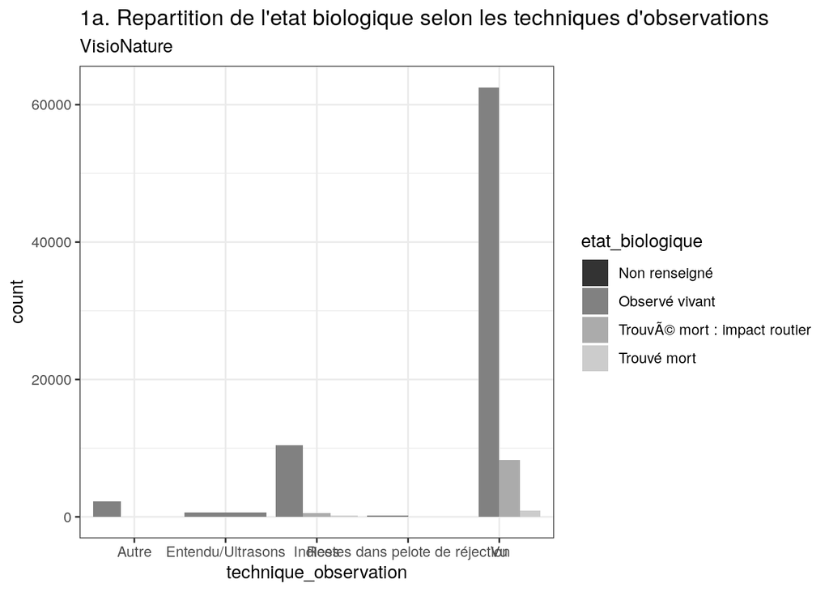

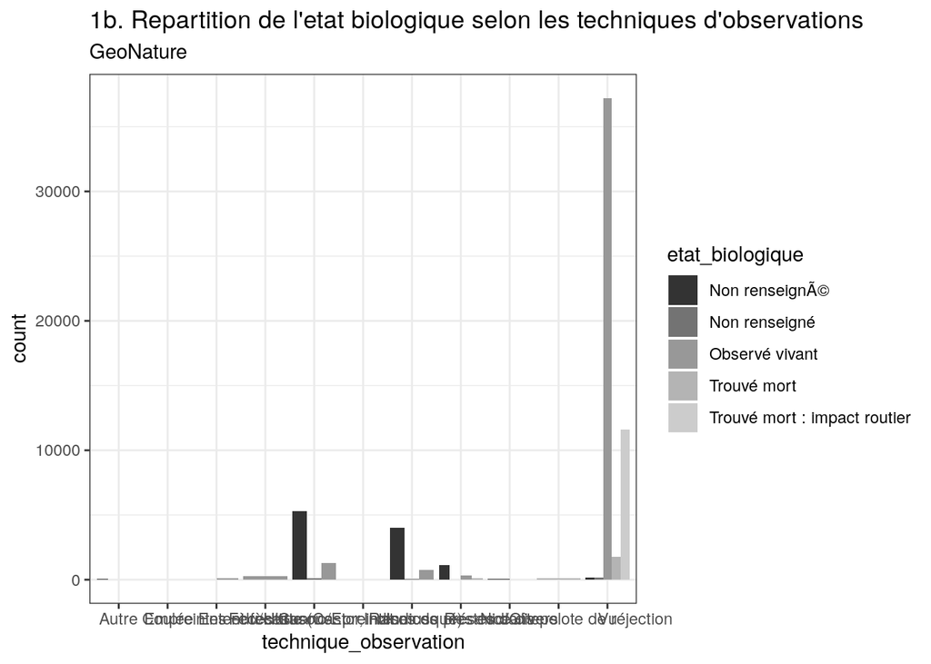

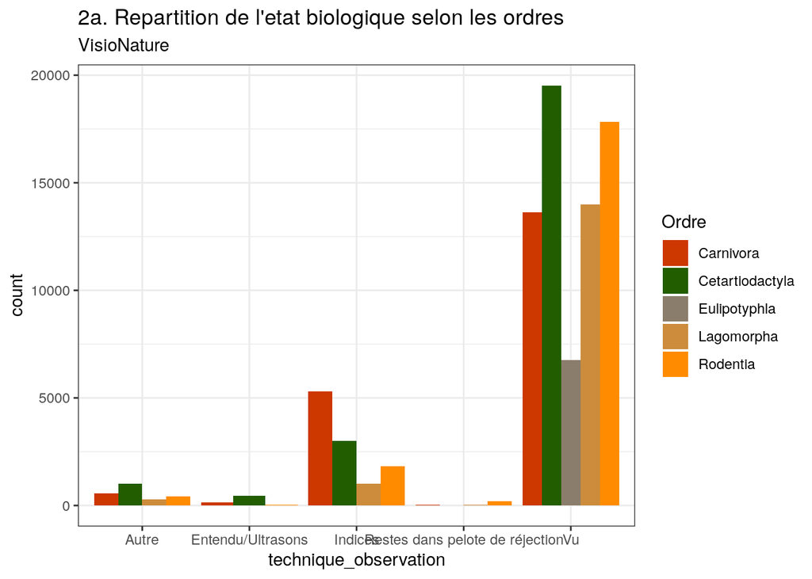

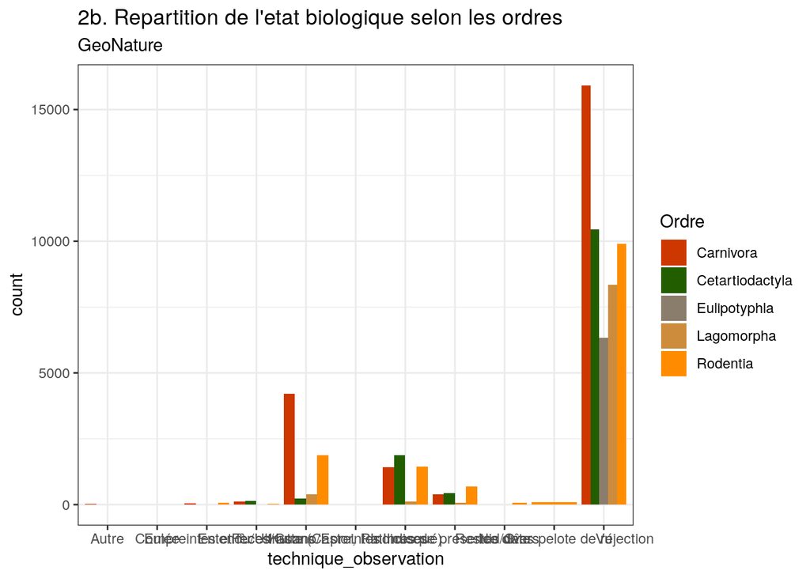

GeoNature observe principalement des indices de rodents et de carnivores. Les lagomorphes sont peu remarques avec les indices, compares aux autres dans VisioNature et GeoNature.

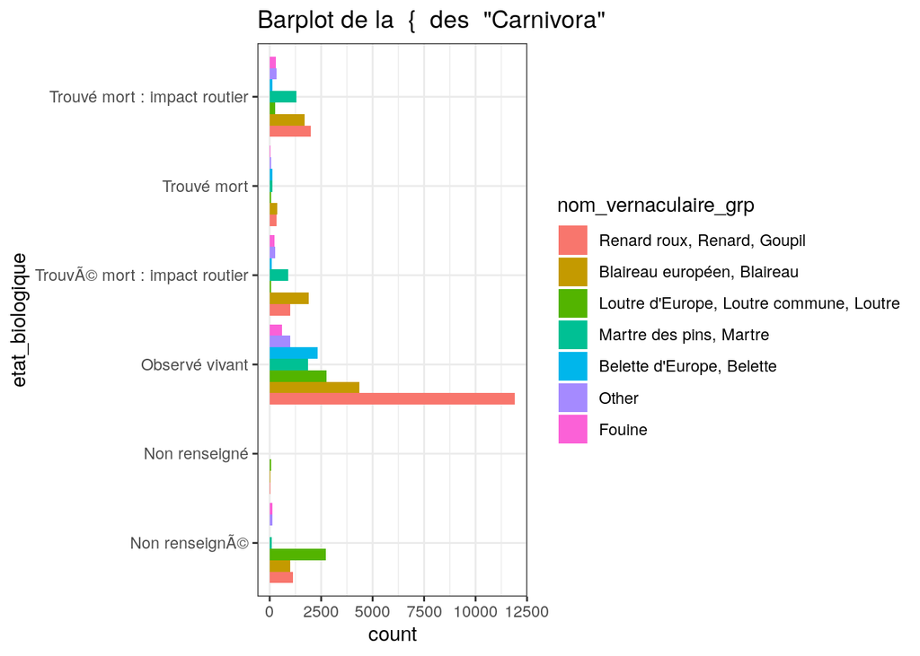

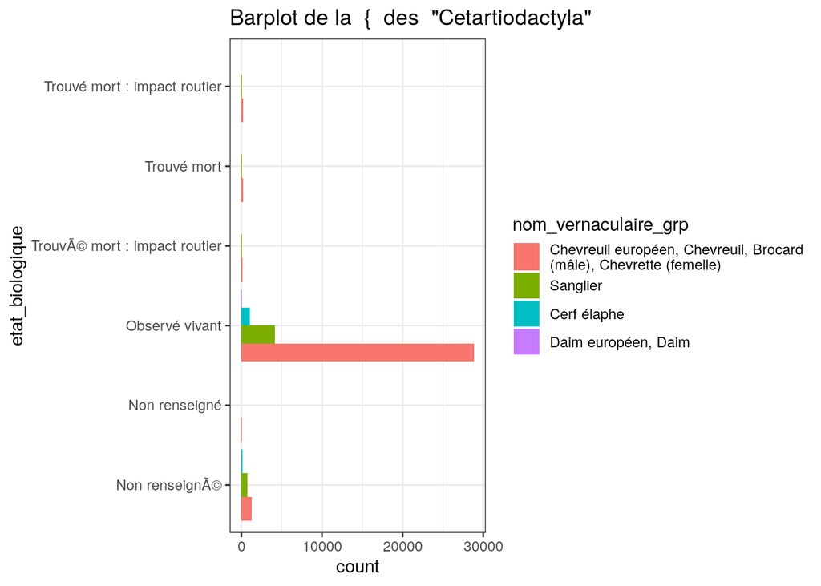

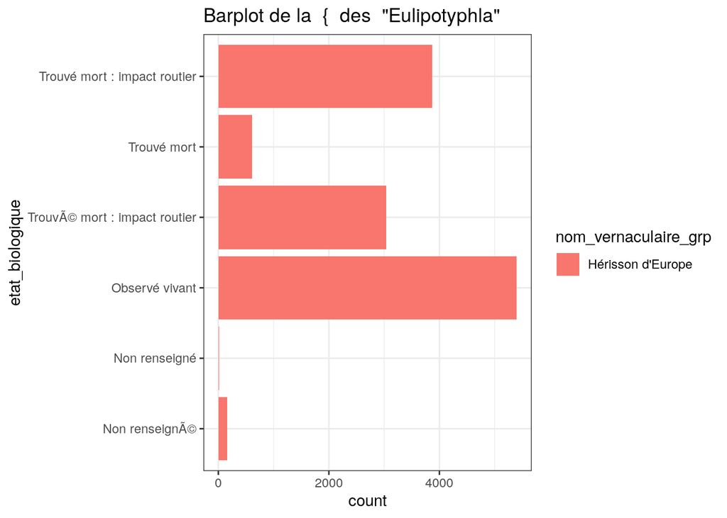

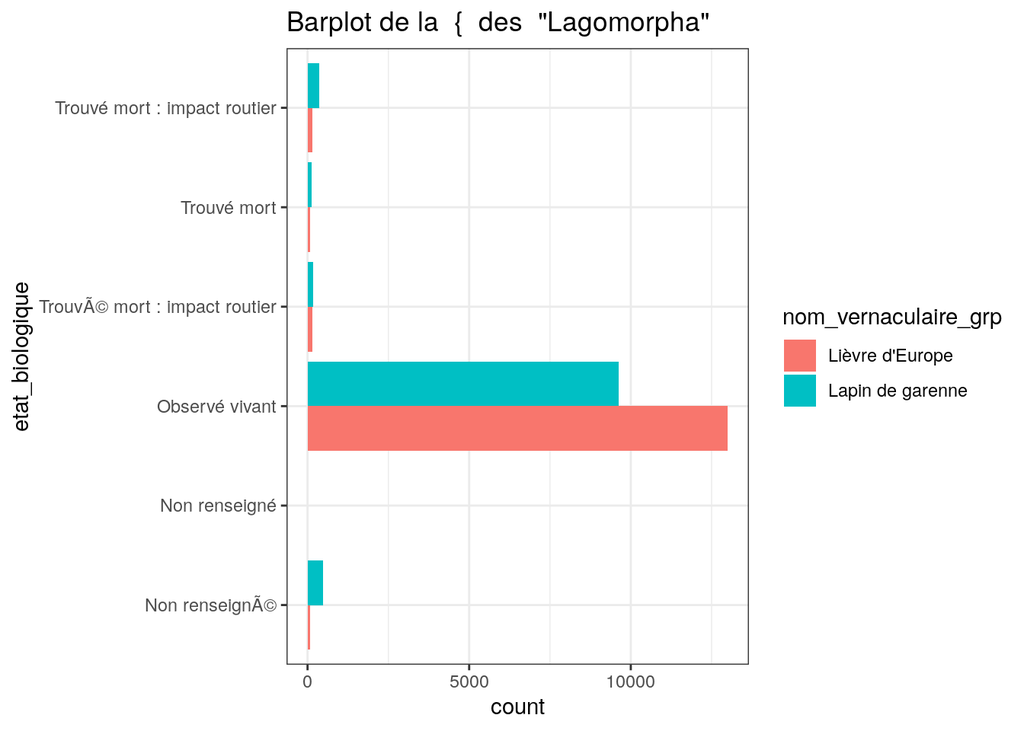

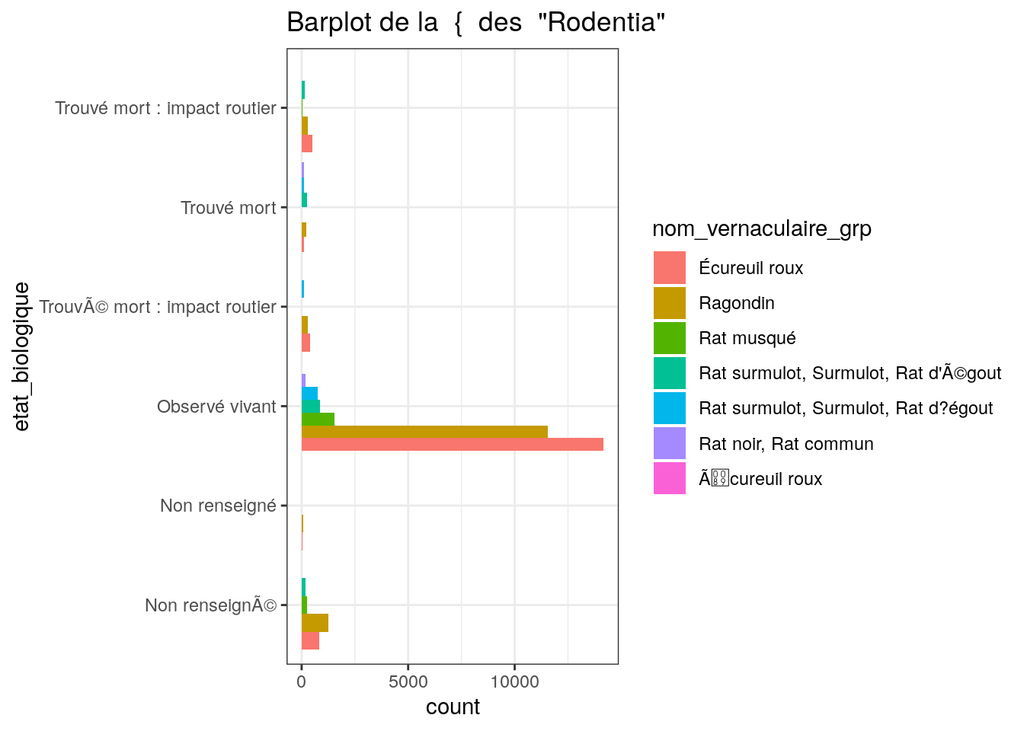

```r
application_tous_ordres(repartition_espece,
                        repartition = etat_biologique)
```

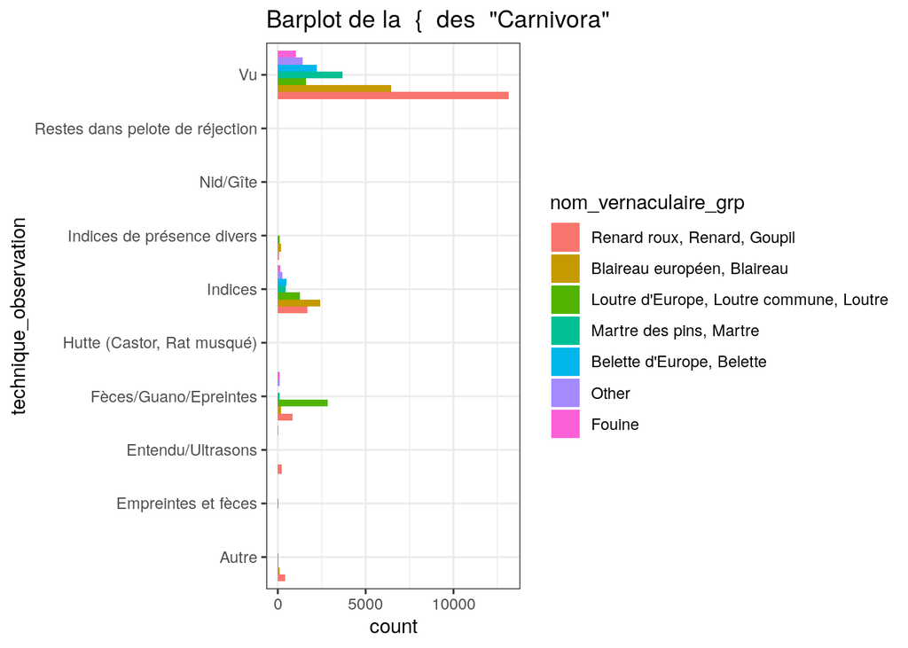

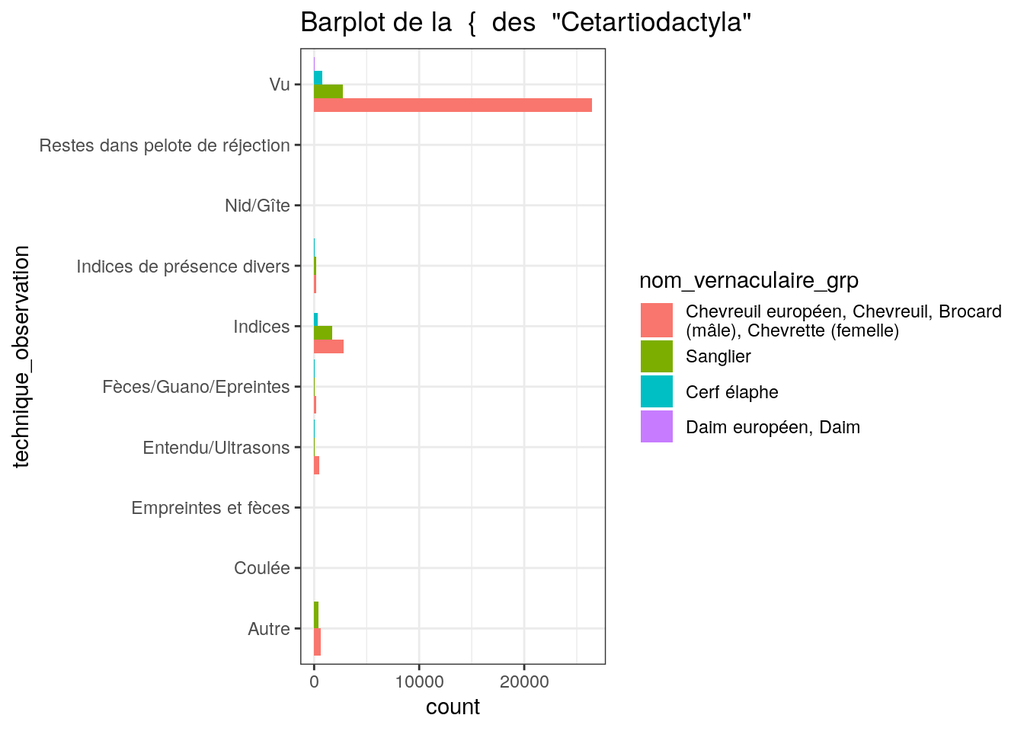

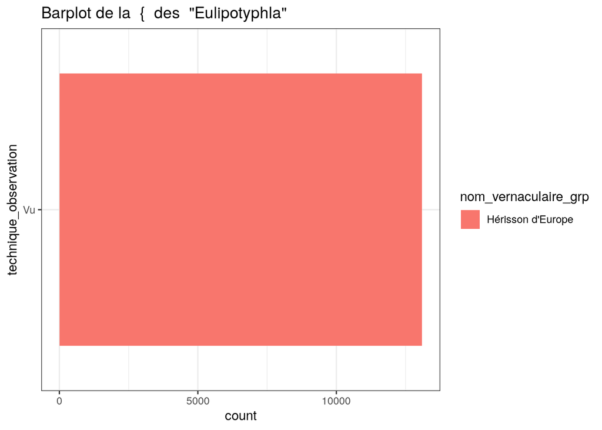

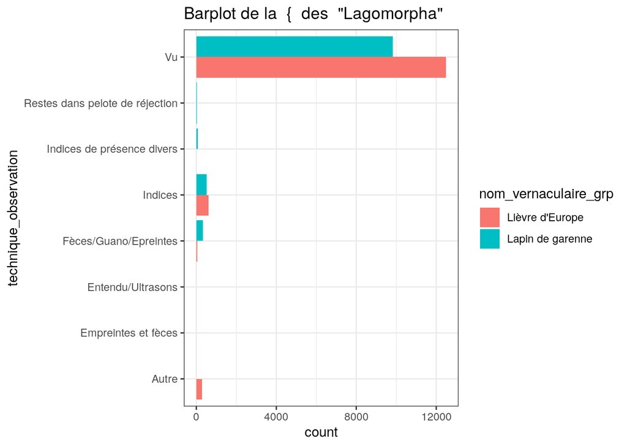

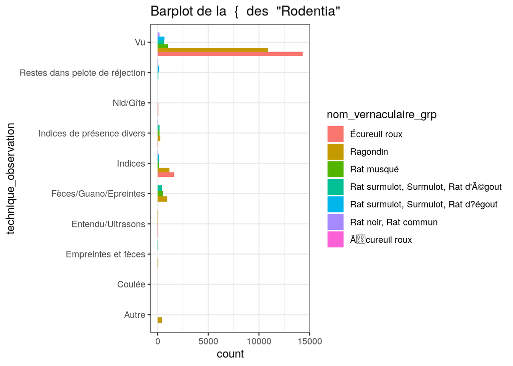

```r
application_tous_ordres(repartition_espece,
                        repartition = technique_observation)
```

### 1.1.1 Repartition des ordres

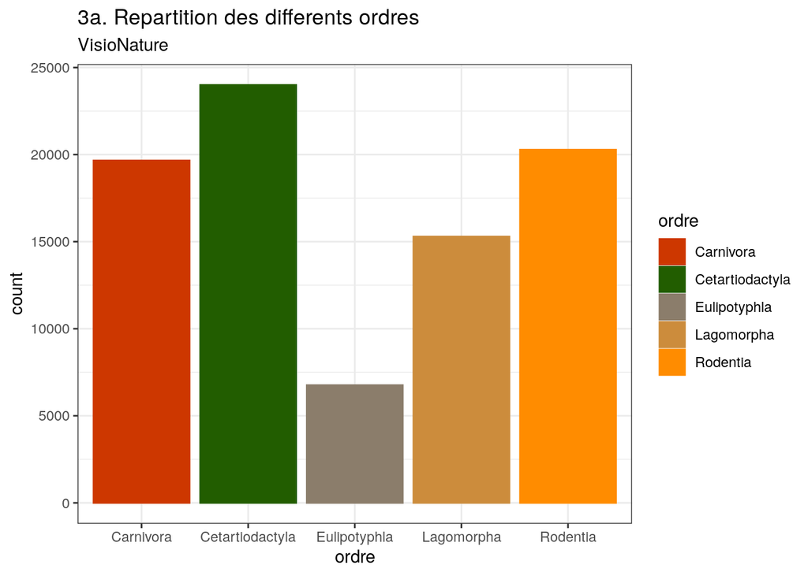

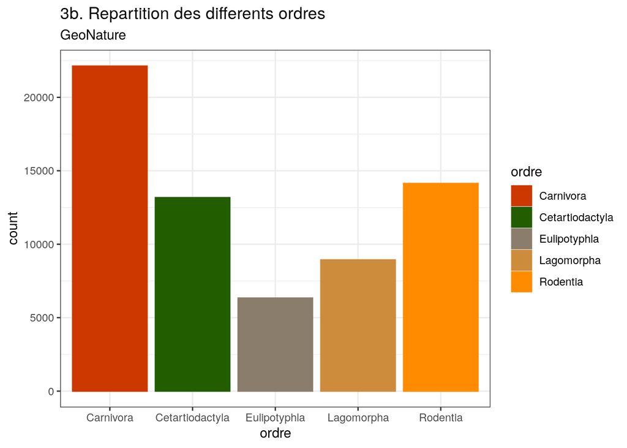

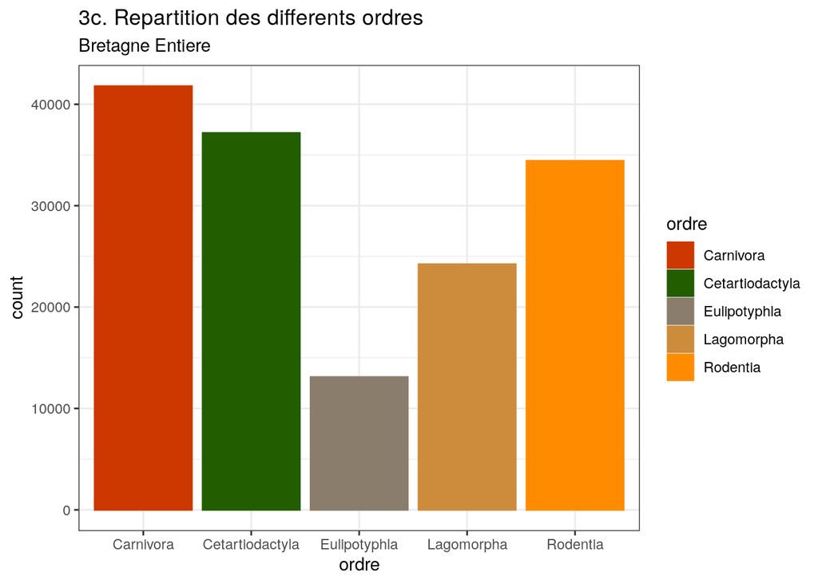

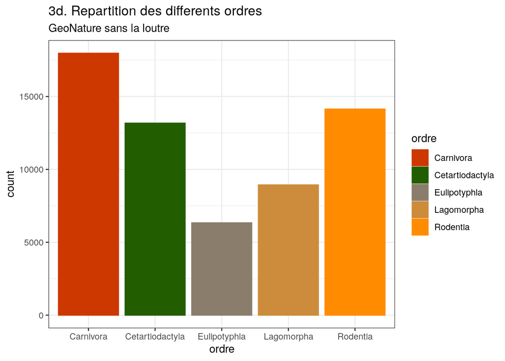

Nous nous sommes demandes a quoi ressemblerait la repartition des ordres sans la loutre car elle est une espece dont le GMB se preoccupe beaucoup. Ca ne change pas drastiquement la distribution.

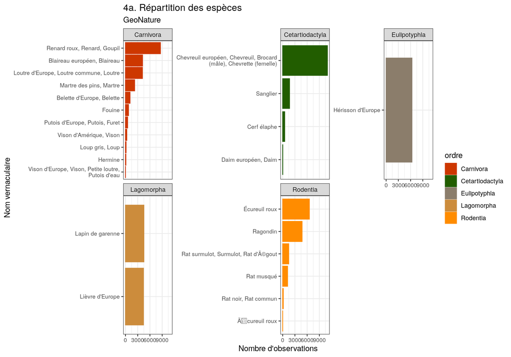

```r
Total%>%
  dplyr::filter(date > params$date_min,
         bdd_originale == "GeoNature")%>%
  count(nom_vernaculaire, ordre, sort = TRUE) %>%
  ggplot2::ggplot(aes(x = reorder(nom_vernaculaire, n),
             y = n, fill = ordre, color = ordre)) +
  geom_col() +
  coord_flip() +
  facet_wrap(~ ordre, scales = "free_y") +
  labs(
    title = "4a. Répartition des espèces",
        subtitle = paste("GeoNature"),
    y = "Nombre d'observations", x = "Nom vernaculaire"
  ) +
  scale_x_discrete(labels = label_wrap(40)) +
  theme_bw()+
  theme(axis.text=element_text(size=8))+
  scale_colour_manual(values=couleur)+
  scale_fill_manual(values = couleur)
```

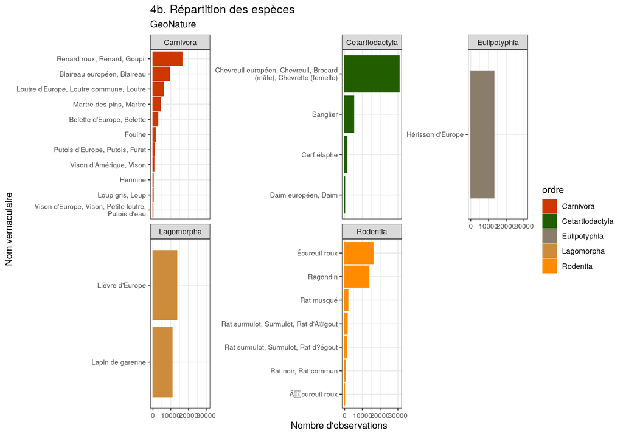

```r
Total%>%
  dplyr::filter(date > params$date_min)%>%
  dplyr::count(nom_vernaculaire, ordre, sort = TRUE) %>%
  ggplot2::ggplot(aes(x = reorder(nom_vernaculaire, n),
             y = n, fill = ordre, color = ordre)) +
  geom_col() +
  coord_flip() +
  facet_wrap(~ ordre, scales = "free_y") +
  labs(
    title = "4b. Répartition des espèces",
        subtitle = paste(GN),
    y = "Nombre d'observations", x = "Nom vernaculaire"
  ) +
  scale_x_discrete(labels = label_wrap(40)) +
  theme_bw()+
  theme(axis.text=element_text(size=8))+
  scale_colour_manual(values=couleur)+
  scale_fill_manual(values = couleur)
```

Nous remarquons une inversion entre les lapins et les lievres entre les deux bases de donnees. Peut-etre lie a la periode pendant laquelle les BDD sont remplies.

## 1.2 2. Description temporelle des bases de donnees

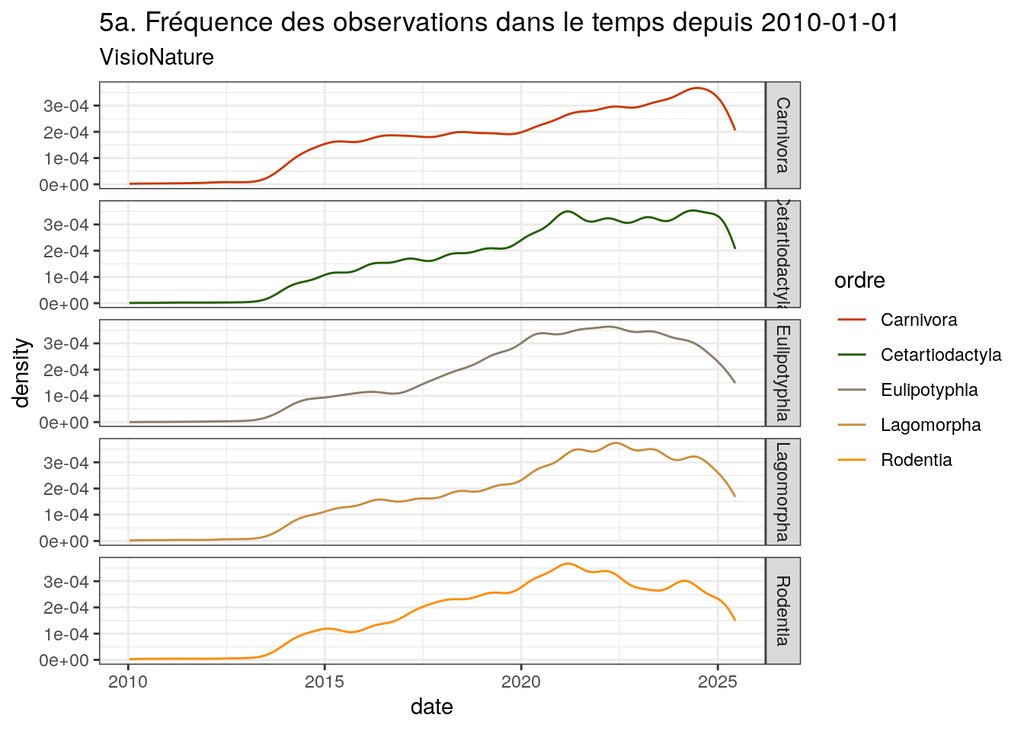

```r
Total%>%
  dplyr::filter(date > params$date_min,
         bdd_originale == VN)%>%
  ggplot2::ggplot(aes(date, color = ordre))+
  labs(title=paste("5a. Fréquence des observations dans le temps depuis", params$date_min),
       subtitle = paste(VN))+
  facet_grid(ordre ~ .)+
  theme_bw()+
  geom_line(stat="density")+
  scale_colour_manual(values=couleur)
```

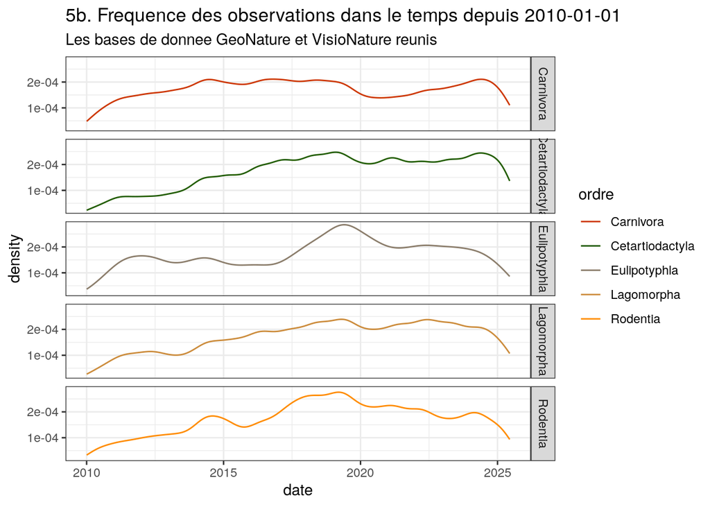

```r
Total%>%
  dplyr::filter(date > params$date_min)%>%
  ggplot2::ggplot(aes(date, color = ordre))+
  labs(title=paste("5b. Frequence des observations dans le temps depuis", params$date_min),
       subtitle = "Les bases de donnee GeoNature et VisioNature reunis")+
  facet_grid(ordre ~ .)+
  theme_bw()+
  geom_line(stat="density")+
  scale_colour_manual(values=couleur)
```

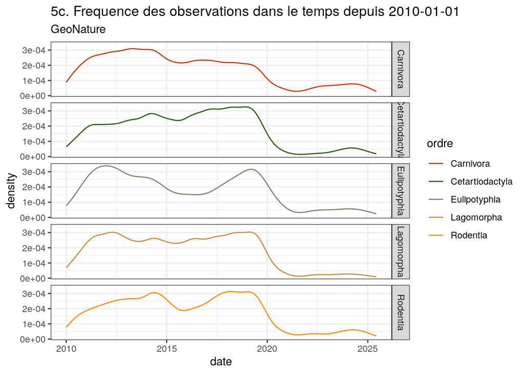

```r
Total%>%
  dplyr::filter(date > params$date_min,
         bdd_originale == GN)%>%
  ggplot2::ggplot(aes(date, color = ordre))+
  labs(title=paste("5c. Frequence des observations dans le temps depuis", params$date_min),
       subtitle = paste(GN))+
  facet_grid(ordre ~ .)+
  theme_bw()+
  geom_line(stat="density")+
  scale_colour_manual(values=couleur)
```

VisioNature a tres peu de donnees avant 2010 et GeoNature avant 1990.

J’aurais focalise l’etude sur la periode [2010 - maintenant] pour les series temporelles, car avant il y a peu de donnees.

Peut-etre que ca pourrait etre interessant de regarder par rapport au nombre d’observateurs? Si il y a plus d’observateurs, alors peut-etre qu’il y aura plus d’observations. Peut-etre qu’on pourra ponderer la dessus?

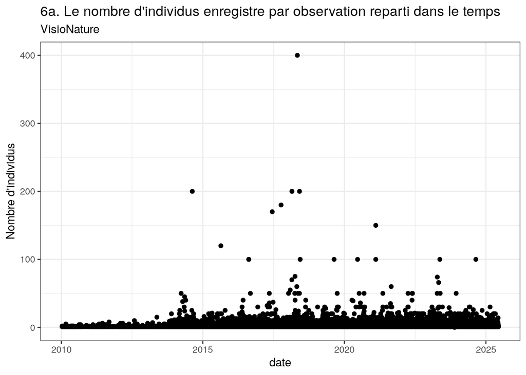

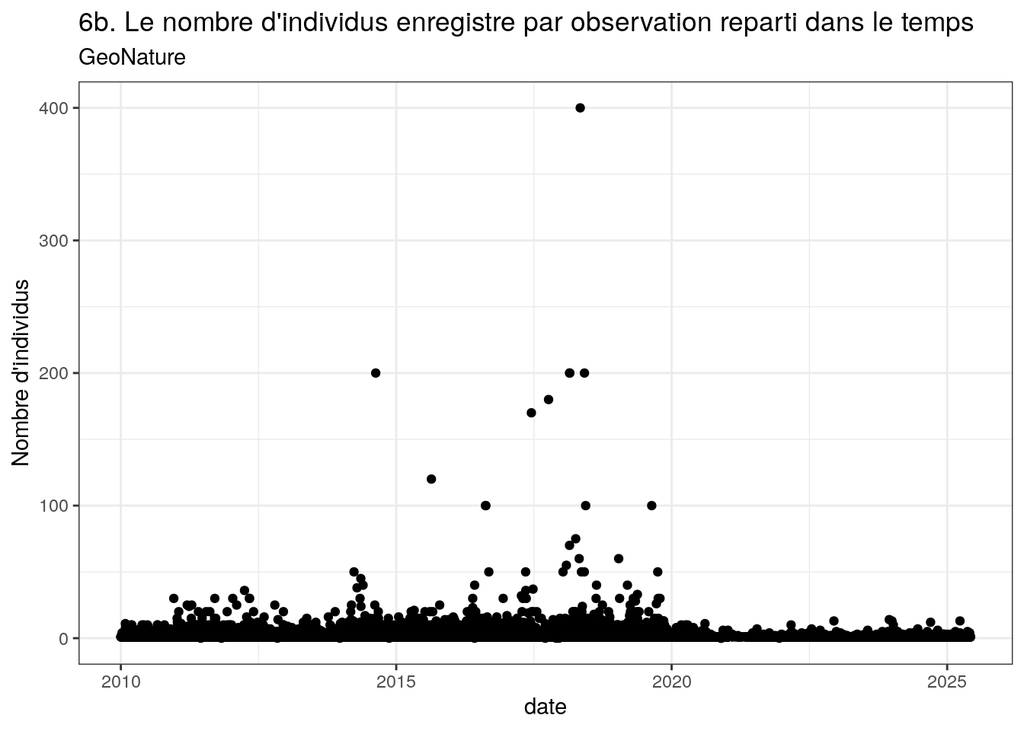

La plupart des observations ne contiennent qu’un animal mais certains en contiennent plusieurs.

Il faudrait peut-etre les prendre en compte, mais les donnees avec beaucoup d’animaux observes (ex: 400 obs d’un coup) risquent de causer des problemes pour creer un modele.

Ensuite, on a essayer d’observer les proportions d’especes dans le temps. Dans “other” il y a toutes les especes qui representent moins de 3% des observations de la periode.

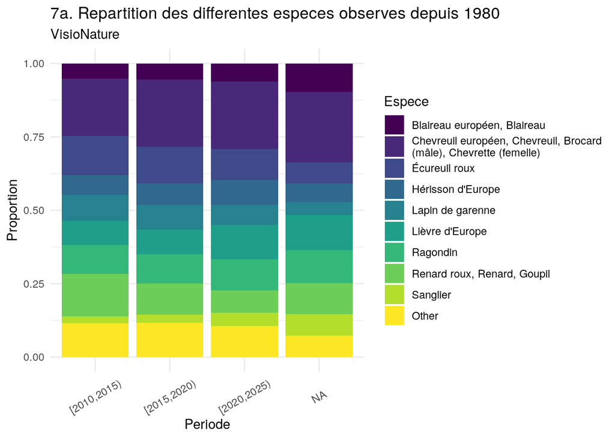

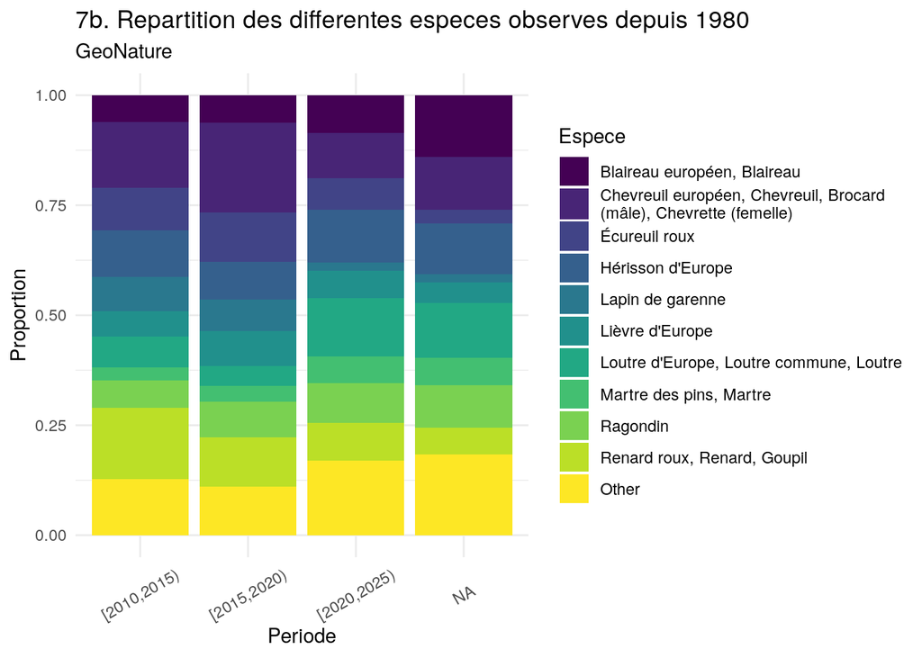

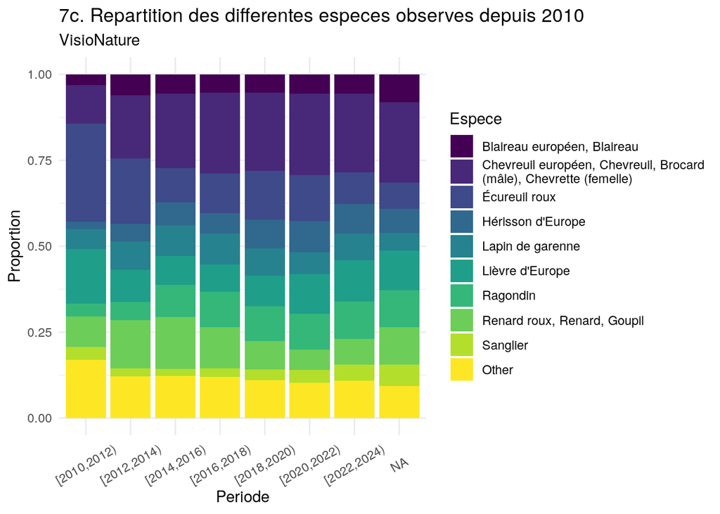

```r
# Depuis 2010

Total%>%
  dplyr::filter(date > params$date_min,
         bdd_originale == VN)%>%
  dplyr::mutate(
    year = as.numeric(format(date, "%Y")),
    year_group = cut(year, breaks = seq(1980, max(year), by = 2), right = FALSE),
    nom_vernaculaire_grp = fct_lump(nom_vernaculaire, prop = 0.03)
  ) %>%
  ggplot2::ggplot(aes(year_group, fill = nom_vernaculaire_grp)) +
  geom_bar(position = "fill") +
  labs(
    title = "7c. Repartition des differentes especes observes depuis 2010",
    x = "Periode",
    subtitle = paste(VN),
    y = "Proportion",
    fill = "Espece"
  ) +
  theme_minimal()+
  scale_fill_viridis_d(labels = label_wrap(40))+
  theme(axis.text.x = element_text(angle = 30, hjust = 0.5, vjust = 0.5))
```

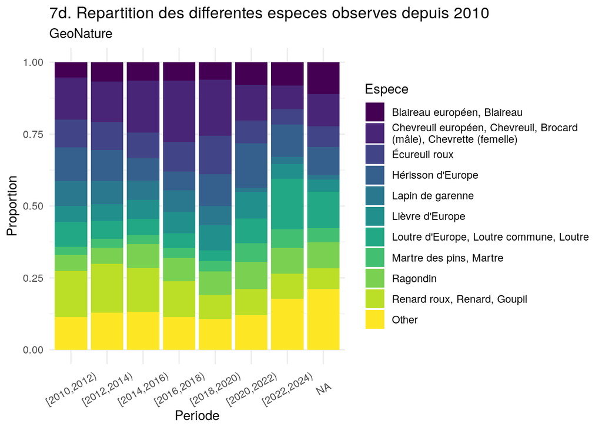

```r
Total%>%
  dplyr::filter(date > params$date_min)%>%
  dplyr::filter(bdd_originale == GN,
         date > as.Date("2010-01-01")) %>%
  dplyr::mutate(
    year = as.numeric(format(date, "%Y")),
    year_group = cut(year,
                     breaks = seq(1980, max(year), by = 2),
                     right = FALSE),
    nom_vernaculaire_grp = fct_lump(nom_vernaculaire, prop = 0.03)
  ) %>%
  ggplot2::ggplot(aes(year_group, fill = nom_vernaculaire_grp)) +
  geom_bar(position = "fill") +
  labs(
    title = "7d. Repartition des differentes especes observes depuis 2010",
    subtitle = paste(GN),
    x = "Periode",
    y = "Proportion",
    fill = "Espece"
  ) +
  theme_minimal()+
  scale_fill_viridis_d(labels = label_wrap(40))+
  theme(axis.text.x = element_text(angle = 30, hjust = 0.5, vjust = 0.5))
```

### 1.2.1 Habitudes des observateurs?

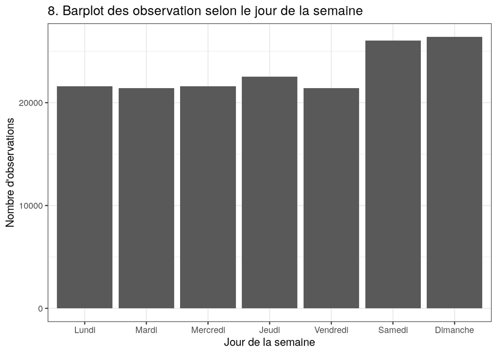

```r
Total%>%
  ggplot2::ggplot(aes(as.factor(wday(date,
                            week_start = getOption("lubridate.week.start", 1)))))+
  labs(title="8. Barplot des observation selon le jour de la semaine",
       y="Nombre d'observations",
       x="Jour de la semaine")+
  theme_bw()+
  geom_bar()+
  scale_x_discrete(labels=c("1" = "Lundi",
                            "2" = "Mardi",
                            "3" = "Mercredi",
                            "4" = "Jeudi",
                            "5" = "Vendredi",
                            "6" = "Samedi",
                            "7" = "Dimanche"))
```

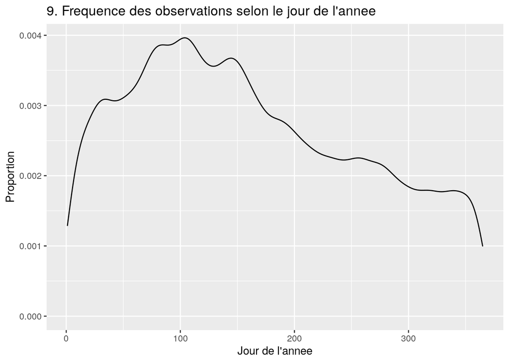

```r
Total %>%
  dplyr::filter(date > params$date_min)%>%
  dplyr::mutate(jour_annee = qday(date)+(quarter(date,with_year = FALSE)-1)*91)%>%
  ggplot2::ggplot(aes(jour_annee)) +
  labs(title="9. Frequence des observations selon le jour de l'annee",
       y="Proportion",
       x="Jour de l'annee")+
  geom_density()
```

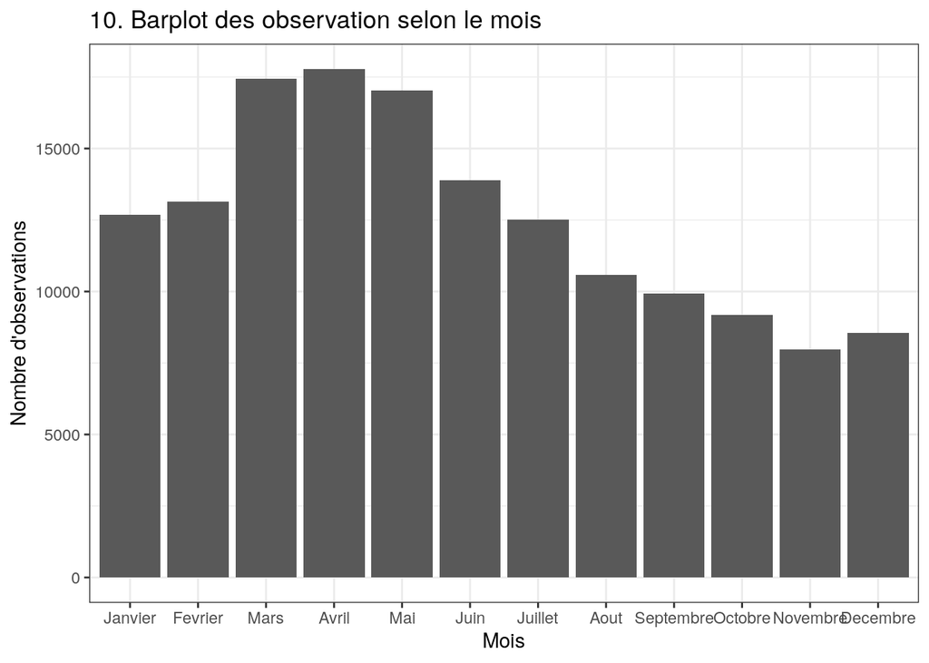

```r
Total%>%
    dplyr::filter(date > params$date_min)%>%
    ggplot2::ggplot(aes(factor(month(date))))+
    labs(title="10. Barplot des observation selon le mois",
         y="Nombre d'observations",
         x="Mois")+
    theme_bw()+
    geom_bar()+
    scale_x_discrete(labels=c("1" = "Janvier",
                              "2" = "Fevrier",
                              "3" = "Mars",
                              "4" = "Avril",
                              "5" = "Mai",
                              "6" = "Juin",
                              "7" = "Juillet",
                              "8" = "Aout",
                              "9" = "Septembre",
                              "10" = "Octobre",
                              "11" = "Novembre",
                              "12" = "Decembre"))
```